# Introduction

> In this notebook, I have built time series models aimed to forecast avocado prices in a region. Two models have benn used Prophet (from facebook) and ARIMA for this purpose. This notebook also demonstrates two methods of validating a model
> - **TSCV**: Time series cross validation, where the data is split into train and test using a time column. An example split is shown below

```
DATA: [0 1 2 3 4 5]

TRAIN: [0] TEST: [1]
TRAIN: [0 1] TEST: [2]
TRAIN: [0 1 2] TEST: [3]
TRAIN: [0 1 2 3] TEST: [4]
TRAIN: [0 1 2 3 4] TEST: [5]
```

> - **One step forecast**: In this case Data is jsut split into train and test. Then a model is built on train data and one step forecast is made. Then the model is updated with that forecast as if it was the observed value and then prediction for next time period is made.

```python
import pandas as pd
import numpy as np

# Plotting libraries
import matplotlib
import matplotlib.pyplot as plt
import seaborn as sns
%matplotlib inline
import janitor

# PROPHET
from plotnine import *
import numpy as np
import pandas as pd
from sklearn.model_selection import TimeSeriesSplit #Splitting for time series CV!
from fbprophet import Prophet

# ARIMA
import pmdarima as pm
from pandas.plotting import lag_plot
from pmdarima.arima import ndiffs
from sklearn.metrics import mean_squared_error
from statsmodels.tsa.arima_model import ARIMA
from statsmodels.tsa.statespace.sarimax import SARIMAX
from statsmodels.graphics.tsaplots import plot_acf, plot_pacf
from statsmodels.tsa.stattools import adfuller
from statsmodels.tsa.seasonal import seasonal_decompose
import warnings
warnings.filterwarnings('ignore')
```

```python
df = pd.read_csv("../avocado.csv")
```

```python
# Removing index column
df.drop('Unnamed: 0', axis=1, inplace=True)

# Removing records with TotalUS region, assuming it is nust the average of all other regions
df = df.loc[df.region!='TotalUS'].reset_index(drop=True)

# Making date to datetime and sorting chrinologically
df['Date'] = pd.to_datetime(df['Date'])
df = df.sort_values('Date')
df = df.clean_names()
```

```python
denver_conventional = df.loc[(df.region=='Denver')&(df.type=='conventional')].reset_index(drop=True)
denver_organic = df.loc[(df.region=='Denver')&(df.type=='organic')].reset_index(drop=True)
denver_conventional.shape,denver_organic.shape
```

```
((169, 13), (169, 13))
```

# Prophet

Source: https://facebook.github.io/prophet/

After expermienting with seasonality, adding/removing regressors, the final model was chosen to be the model with weekly seasonality with few regressors. The rmse error dropped from 0.31(no seasonality) to 0.2(weekly with regressors)

## Conventional

```python
prophet_df=denver_conventional.rename(columns={"date": "ds", "averageprice": "y"})
prophet_df=prophet_df.sort_values("ds").reset_index(drop=True)
```

```python
tscv = TimeSeriesSplit(n_splits=5)
```

```python
prophet_df.shape
```

```
(169, 13)
```

```python
output=pd.DataFrame()
for i,(train_index,test_index) in enumerate(tscv.split(prophet_df)):
    print(f"FOLD: {i}")
    final_df = pd.DataFrame()
    train_df=prophet_df.copy().iloc[train_index,:]
    test_df=prophet_df.copy().iloc[test_index,:]

    m=Prophet(seasonality_mode='multiplicative',
            yearly_seasonality=False,
            weekly_seasonality=True,
            daily_seasonality=False
        )

    m.add_regressor('total_volume')
    #m.add_regressor('4046')
    #m.add_regressor('4225')
    m.add_regressor('4770')
    m.add_regressor('total_bags')
    #m.add_regressor('small_bags')
    m.add_regressor('large_bags')
    m.add_regressor('xlarge_bags')

    m.fit(train_df)
    predictions=m.predict(test_df)
    pred_df=predictions.loc[:,["ds","yhat"]]
    #pred_df['yhat'] = pred_df['yhat'].apply(lambda x: 0 if x<0 else x)
    pred_df["y"]=test_df.y.tolist()
    pred_df["total_volume"]=test_df.total_volume.tolist()
    pred_df["4046"]=test_df['4046'].tolist()
    pred_df["4225"]=test_df['4225'].tolist()
    pred_df["4770"]=test_df['4770'].tolist()
    pred_df["total_bags"]=test_df.total_bags.tolist()
    pred_df["small_bags"]=test_df.small_bags.tolist()
    pred_df["large_bags"]=test_df.large_bags.tolist()
    pred_df["xlarge_bags"]=test_df.xlarge_bags.tolist()


    train_df["indicator"]="Train"
    pred_df["indicator"]="Test"
    final_df=train_df.append(pred_df).reset_index(drop=True)
    final_df["fold"]="Fold "+str(i+1)
    final_df["rmse"]=np.sqrt((np.mean((final_df.yhat-final_df.y)**2)))
    output = output.append(final_df).reset_index(drop=True)
```

```
INFO:fbprophet:n_changepoints greater than number of observations.Using 22.
```

```
FOLD: 0
FOLD: 1
FOLD: 2
FOLD: 3
FOLD: 4
```

```python
from fbprophet.diagnostics import cross_validation
from fbprophet.diagnostics import performance_metrics
cross_validation_results = cross_validation(m, initial='210 days', period='15 days', horizon='70 days')
```

```
INFO:fbprophet:Making 47 forecasts with cutoffs between 2015-08-12 00:00:00 and 2017-07-02 00:00:00
INFO:fbprophet:n_changepoints greater than number of observations.Using 24.
```

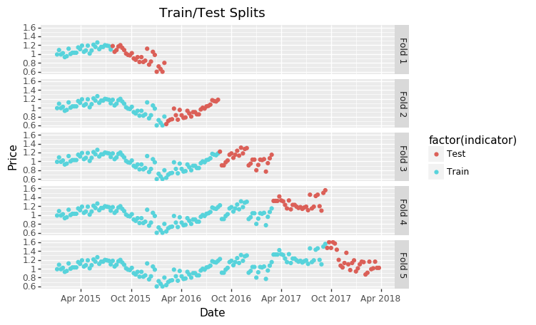

```python
(ggplot(output,aes("ds","y",color="factor(indicator)"))+\
 geom_point()+facet_grid('fold~.'))+\
labs(title="Train/Test Splits",x="Date",y="Price")+\
scale_x_date(date_breaks="6 months",date_labels =  "%b %Y")
```

```python
output.groupby('fold').agg({'rmse':'mean'}).reset_index()
```

|  | fold | rmse |
| --- | --- | --- |
| 0 | Fold 1 | 0.279742 |
| 1 | Fold 2 | 0.090420 |
| 2 | Fold 3 | 0.257987 |
| 3 | Fold 4 | 0.181904 |
| 4 | Fold 5 | 0.249073 |

## Organic

```python
prophet_df=denver_organic.rename(columns={"date": "ds", "averageprice": "y"})
prophet_df=prophet_df.sort_values("ds").reset_index(drop=True)
```

```python
tscv = TimeSeriesSplit(n_splits=5)
```

```python
prophet_df.shape
```

```
(169, 13)
```

```python
output=pd.DataFrame()
for i,(train_index,test_index) in enumerate(tscv.split(prophet_df)):
    print(f"FOLD: {i}")
    final_df = pd.DataFrame()
    train_df=prophet_df.copy().iloc[train_index,:]
    test_df=prophet_df.copy().iloc[test_index,:]

    m=Prophet(
            yearly_seasonality=False,
            weekly_seasonality=True,
            daily_seasonality=False
        )

    m.add_regressor('total_volume')
    #m.add_regressor('4046')
    #m.add_regressor('4225')
    m.add_regressor('4770')
    m.add_regressor('total_bags')
    #m.add_regressor('small_bags')
    m.add_regressor('large_bags')
    m.add_regressor('xlarge_bags')

    m.fit(train_df)
    predictions=m.predict(test_df)
    pred_df=predictions.loc[:,["ds","yhat"]]
    pred_df['yhat'] = pred_df['yhat'].apply(lambda x: 0 if x<0 else x)
    pred_df["y"]=test_df.y.tolist()
    pred_df["total_volume"]=test_df.total_volume.tolist()
    pred_df["4046"]=test_df['4046'].tolist()
    pred_df["4225"]=test_df['4225'].tolist()
    pred_df["4770"]=test_df['4770'].tolist()
    pred_df["total_bags"]=test_df.total_bags.tolist()
    pred_df["small_bags"]=test_df.small_bags.tolist()
    pred_df["large_bags"]=test_df.large_bags.tolist()
    pred_df["xlarge_bags"]=test_df.xlarge_bags.tolist()


    train_df["indicator"]="Train"
    pred_df["indicator"]="Test"
    final_df=train_df.append(pred_df).reset_index(drop=True)
    final_df["fold"]="Fold "+str(i+1)
    final_df["rmse"]=np.sqrt((np.mean((final_df.yhat-final_df.y)**2)))
    output = output.append(final_df).reset_index(drop=True)
```

```
INFO:fbprophet:n_changepoints greater than number of observations.Using 22.
```

```
FOLD: 0
FOLD: 1
FOLD: 2
FOLD: 3
FOLD: 4
```

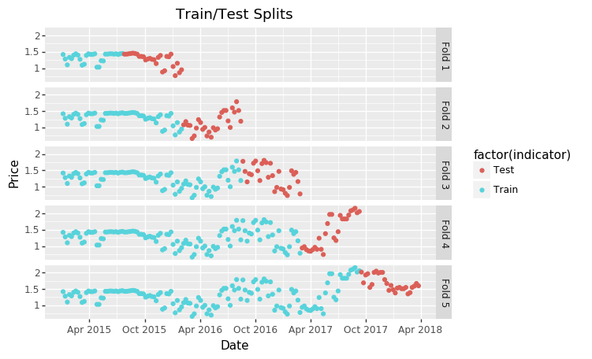

```python
(ggplot(output,aes("ds","y",color="factor(indicator)"))+\
 geom_point()+facet_grid('fold~.'))+\
labs(title="Train/Test Splits",x="Date",y="Price")+\
scale_x_date(date_breaks="6 months",date_labels =  "%b %Y")
```

```python
output.groupby('fold').agg({'rmse':'mean'}).reset_index()
```

|  | fold | rmse |
| --- | --- | --- |
| 0 | Fold 1 | 0.294722 |
| 1 | Fold 2 | 0.390485 |
| 2 | Fold 3 | 0.271514 |
| 3 | Fold 4 | 0.504493 |
| 4 | Fold 5 | 0.235600 |

# ARIMA

## Conventional

```python
denver_conventional = denver_conventional.sort_values('date')
```

### Split data into train and test

```python
train_len = int(denver_conventional.shape[0] * 0.8)
train_data, test_data = denver_conventional[:train_len], denver_conventional[train_len:]

y_train = train_data['averageprice'].values
y_test = test_data['averageprice'].values

print(f"{train_len} train samples")
print(f"{denver_conventional.shape[0] - train_len} test samples")
```

```
135 train samples
34 test samples
```

### Check for stationarity

> Using autocorrelation plot see what lags are important. We see that before diffrencing we have first few lags correlated and p-value for stationarity test is 0.30 (high). But after differencing (pvalue~0) and still see some small spikes in lags.

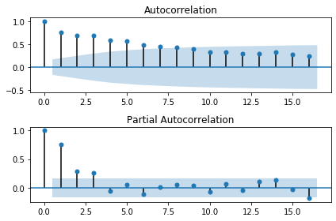

```python
ax = plt.subplot(211)

# Plot the autocorrelation function
plot_acf(y_train.squeeze(), lags=16, ax=ax)
ax = plt.subplot(212)
plot_pacf(y_train.squeeze(), lags=16, ax=ax)
plt.tight_layout()
```

```
Dickey–Fuller test: p=0.303443
```

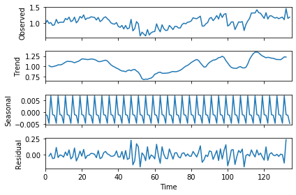

```python
seasonal_decompose(y_train, model='additive',freq=4).plot()
print("Dickey–Fuller test: p=%f" % adfuller(y_train)[1])
```

```python
y_train_diff = train_data['averageprice'].diff()[1:].values
```

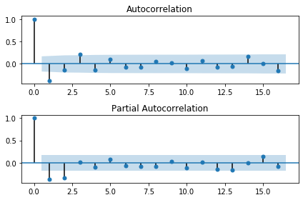

```python
ax = plt.subplot(211)

# Plot the autocorrelation function
plot_acf(y_train_diff.squeeze(), lags=16, ax=ax)
ax = plt.subplot(212)
plot_pacf(y_train_diff.squeeze(), lags=16, ax=ax)
plt.tight_layout()
```

```
Dickey–Fuller test: p=0.000000
```

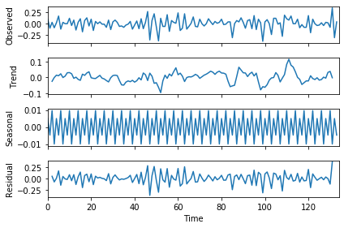

```python
seasonal_decompose(y_train_diff, model='additive',freq=4).plot()
print("Dickey–Fuller test: p=%f" % adfuller(y_train_diff)[1])
```

### Lag Plot

> Lag plot to see if the correlated lags are linear or non-linear. The plots show that the relationship between the lags are quite linear, so auto-regressive models will help in case of forecasting.

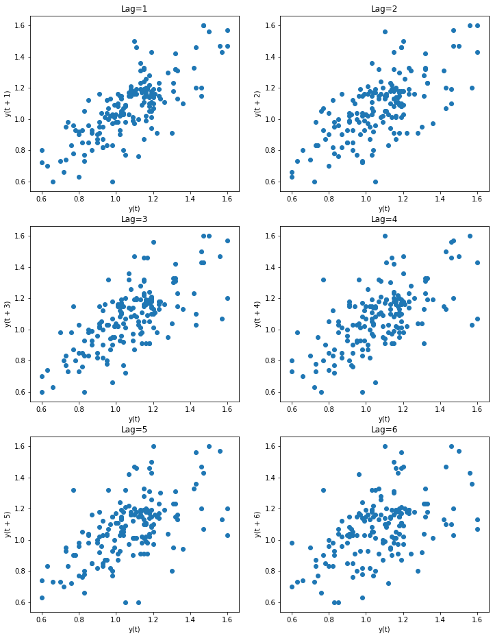

```python
from pandas.plotting import lag_plot

fig, axes = plt.subplots(3, 2, figsize=(12, 16))
plt.title('Autocorrelation plot')

# The axis coordinates for the plots
ax_idcs = [
    (0, 0),
    (0, 1),
    (1, 0),
    (1, 1),
    (2, 0),
    (2, 1)
]

for lag, ax_coords in enumerate(ax_idcs, 1):
    ax_row, ax_col = ax_coords
    axis = axes[ax_row][ax_col]
    lag_plot(denver_conventional['averageprice'], lag=lag, ax=axis)
    axis.set_title(f"Lag={lag}")

plt.show()
```

All lags look fairly linear, so it's a good indicator that an auto-regressive model is a good choice. Therefore, we'll allow the auto_arima to select the lag term

```python
from pmdarima.arima import ndiffs

kpss_diffs = ndiffs(y_train, alpha=0.05, test='kpss', max_d=6)
adf_diffs = ndiffs(y_train, alpha=0.05, test='adf', max_d=6)
n_diffs = max(adf_diffs, kpss_diffs)

print(f"Estimated differencing term: {n_diffs}")
```

```
Estimated differencing term: 1
```

### Auto - ARIMA

```python
auto = pm.auto_arima(y_train, start_p=1, start_q=1,
                           max_p=6, max_q=6, m=12,
                           start_P=0, seasonal=True,
                           d=1, D=1, trace=True,
                           error_action='ignore',
                           suppress_warnings=True,
                           stepwise=True,random=True)
```

```
Fit ARIMA: order=(1, 1, 1) seasonal_order=(0, 1, 1, 12); AIC=-147.339, BIC=-133.318, Fit time=1.392 seconds
Fit ARIMA: order=(0, 1, 0) seasonal_order=(0, 1, 0, 12); AIC=-64.926, BIC=-59.318, Fit time=0.114 seconds
Fit ARIMA: order=(1, 1, 0) seasonal_order=(1, 1, 0, 12); AIC=-109.417, BIC=-98.201, Fit time=0.389 seconds
Fit ARIMA: order=(0, 1, 1) seasonal_order=(0, 1, 1, 12); AIC=-149.304, BIC=-138.088, Fit time=0.967 seconds
Fit ARIMA: order=(0, 1, 1) seasonal_order=(1, 1, 1, 12); AIC=-147.714, BIC=-133.694, Fit time=0.908 seconds
Fit ARIMA: order=(0, 1, 1) seasonal_order=(0, 1, 0, 12); AIC=-86.124, BIC=-77.712, Fit time=0.080 seconds
Fit ARIMA: order=(0, 1, 1) seasonal_order=(0, 1, 2, 12); AIC=-147.762, BIC=-133.742, Fit time=2.772 seconds
Fit ARIMA: order=(0, 1, 1) seasonal_order=(1, 1, 2, 12); AIC=-145.736, BIC=-128.912, Fit time=3.683 seconds
Fit ARIMA: order=(0, 1, 0) seasonal_order=(0, 1, 1, 12); AIC=-122.371, BIC=-113.959, Fit time=0.484 seconds
Fit ARIMA: order=(0, 1, 2) seasonal_order=(0, 1, 1, 12); AIC=-147.374, BIC=-133.354, Fit time=1.222 seconds
Fit ARIMA: order=(1, 1, 2) seasonal_order=(0, 1, 1, 12); AIC=-151.613, BIC=-134.789, Fit time=1.248 seconds
Fit ARIMA: order=(1, 1, 2) seasonal_order=(1, 1, 1, 12); AIC=-149.834, BIC=-130.206, Fit time=1.617 seconds
Fit ARIMA: order=(1, 1, 2) seasonal_order=(0, 1, 0, 12); AIC=-94.971, BIC=-80.951, Fit time=0.416 seconds
Fit ARIMA: order=(1, 1, 2) seasonal_order=(0, 1, 2, 12); AIC=-150.285, BIC=-130.657, Fit time=3.998 seconds
Fit ARIMA: order=(1, 1, 2) seasonal_order=(1, 1, 2, 12); AIC=-147.812, BIC=-125.380, Fit time=5.708 seconds
Fit ARIMA: order=(2, 1, 2) seasonal_order=(0, 1, 1, 12); AIC=-152.374, BIC=-132.746, Fit time=1.979 seconds
Fit ARIMA: order=(2, 1, 1) seasonal_order=(0, 1, 1, 12); AIC=-150.807, BIC=-133.983, Fit time=1.562 seconds
Fit ARIMA: order=(2, 1, 3) seasonal_order=(0, 1, 1, 12); AIC=-150.446, BIC=-128.014, Fit time=2.741 seconds
Fit ARIMA: order=(3, 1, 3) seasonal_order=(0, 1, 1, 12); AIC=-148.166, BIC=-122.930, Fit time=2.242 seconds
Fit ARIMA: order=(2, 1, 2) seasonal_order=(1, 1, 1, 12); AIC=-151.267, BIC=-128.835, Fit time=1.811 seconds
Fit ARIMA: order=(2, 1, 2) seasonal_order=(0, 1, 0, 12); AIC=-93.990, BIC=-77.165, Fit time=0.540 seconds
Fit ARIMA: order=(2, 1, 2) seasonal_order=(0, 1, 2, 12); AIC=-151.386, BIC=-128.954, Fit time=3.808 seconds
Fit ARIMA: order=(2, 1, 2) seasonal_order=(1, 1, 2, 12); AIC=-148.954, BIC=-123.718, Fit time=3.906 seconds
Fit ARIMA: order=(3, 1, 2) seasonal_order=(0, 1, 1, 12); AIC=-150.147, BIC=-127.715, Fit time=1.592 seconds
Total fit time: 45.188 seconds
```

```python
auto.summary()
```

Statespace Model Results

| Dep. Variable: | y | No. Observations: | 135 |
| --- | --- | --- | --- |
| Model: | SARIMAX(2, 1, 2)x(0, 1, 1, 12) | Log Likelihood | 83.187 |
| Date: | Thu, 07 Nov 2019 | AIC | -152.374 |
| Time: | 17:58:35 | BIC | -132.746 |
| Sample: | 0 | HQIC | -144.402 |
|  | - 135 |  |  |
| Covariance Type: | opg |  |  |

|  | coef | std err | z | P>\|z\| | [0.025 | 0.975] |
| --- | --- | --- | --- | --- | --- | --- |
| intercept | 0.0012 | 0.003 | 0.353 | 0.724 | -0.006 | 0.008 |
| ar.L1 | -0.9178 | 0.184 | -4.994 | 0.000 | -1.278 | -0.558 |
| ar.L2 | -0.2880 | 0.178 | -1.622 | 0.105 | -0.636 | 0.060 |
| ma.L1 | 0.4776 | 0.188 | 2.538 | 0.011 | 0.109 | 0.846 |
| ma.L2 | -0.3074 | 0.192 | -1.601 | 0.109 | -0.684 | 0.069 |
| ma.S.L12 | -0.9060 | 0.190 | -4.776 | 0.000 | -1.278 | -0.534 |
| sigma2 | 0.0128 | 0.002 | 5.852 | 0.000 | 0.008 | 0.017 |

| Ljung-Box (Q): | 38.07 | Jarque-Bera (JB): | 0.52 |
| --- | --- | --- | --- |
| Prob(Q): | 0.56 | Prob(JB): | 0.77 |
| Heteroskedasticity (H): | 2.00 | Skew: | -0.00 |
| Prob(H) (two-sided): | 0.03 | Kurtosis: | 3.32 |

Warnings:  
[1] Covariance matrix calculated using the outer product of gradients (complex-step).

```python
print(auto.order)
```

```
(2, 1, 2)
```

### Forecasting

```python
from sklearn.metrics import mean_squared_error

model = auto

def forecast_one_step():
    fc, conf_int = model.predict(n_periods=1, return_conf_int=True)
    return (
        fc.tolist()[0],
        np.asarray(conf_int).tolist()[0])

forecasts = []
confidence_intervals = []

for new_ob in y_test:
    fc, conf = forecast_one_step()
    forecasts.append(fc)
    confidence_intervals.append(conf)

    # Updates the existing model with a small number of MLE steps
    model.update([fc])

print(f"Mean squared error: {mean_squared_error(y_test, forecasts)}")
```

```
Mean squared error: 0.08849193704570399
```

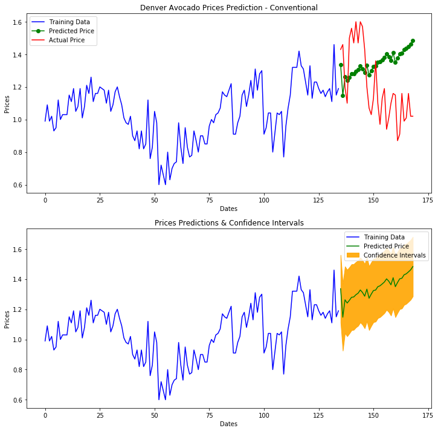

```python
fig, axes = plt.subplots(2, 1, figsize=(12, 12))
axes[0].plot(y_train, color='blue', label='Training Data')
axes[0].plot(test_data.index, forecasts, color='green', marker='o',label='Predicted Price')

axes[0].plot(test_data.index, y_test, color='red', label='Actual Price')
axes[0].set_title('Denver Avocado Prices Prediction - Conventional')
axes[0].set_xlabel('Dates')
axes[0].set_ylabel('Prices')
axes[0].legend()


axes[1].plot(y_train, color='blue', label='Training Data')
axes[1].plot(test_data.index, forecasts, color='green',
             label='Predicted Price')

axes[1].set_title('Prices Predictions & Confidence Intervals')
axes[1].set_xlabel('Dates')
axes[1].set_ylabel('Prices')

conf_int = np.asarray(confidence_intervals)
axes[1].fill_between(test_data.index,
                     conf_int[:, 0], conf_int[:, 1],
                     alpha=0.9, color='orange',
                     label="Confidence Intervals")
axes[1].legend()
```

## Organic

```python
denver_organic = denver_organic.sort_values('date')
```

```python
train_len = int(denver_organic.shape[0] * 0.8)
train_data, test_data = denver_organic[:train_len], denver_organic[train_len:]

y_train = train_data['averageprice'].values
y_test = test_data['averageprice'].values

print(f"{train_len} train samples")
print(f"{denver_conventional.shape[0] - train_len} test samples")
```

```
135 train samples
34 test samples
```

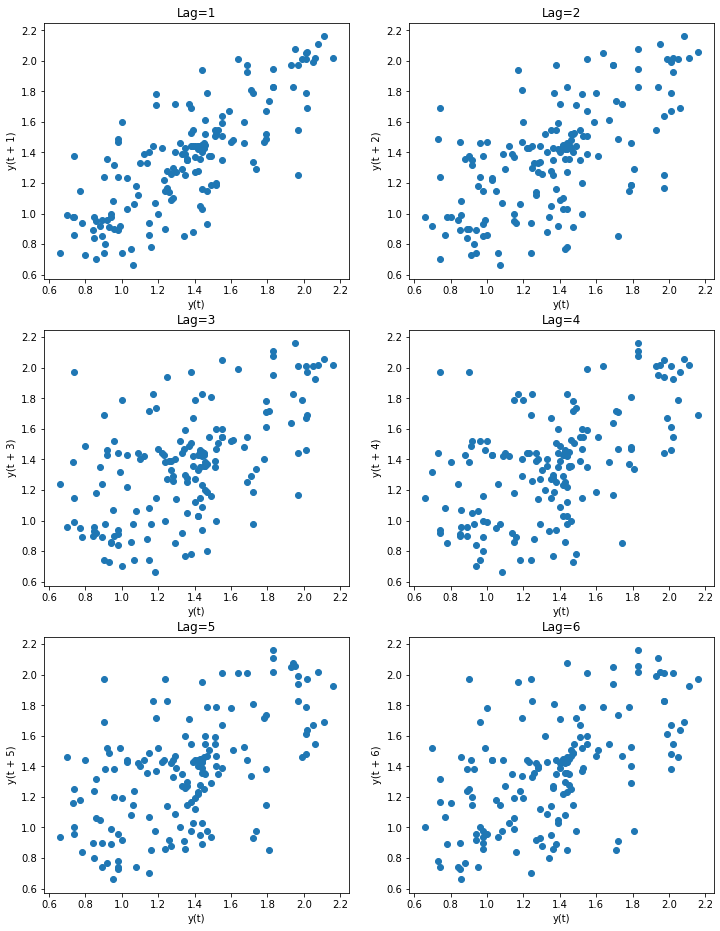

```python
from pandas.plotting import lag_plot

fig, axes = plt.subplots(3, 2, figsize=(12, 16))
plt.title('Autocorrelation plot')

# The axis coordinates for the plots
ax_idcs = [
    (0, 0),
    (0, 1),
    (1, 0),
    (1, 1),
    (2, 0),
    (2, 1)
]

for lag, ax_coords in enumerate(ax_idcs, 1):
    ax_row, ax_col = ax_coords
    axis = axes[ax_row][ax_col]
    lag_plot(denver_organic['averageprice'], lag=lag, ax=axis)
    axis.set_title(f"Lag={lag}")

plt.show()
```

```python
from pmdarima.arima import ndiffs

kpss_diffs = ndiffs(y_train, alpha=0.05, test='kpss', max_d=6)
adf_diffs = ndiffs(y_train, alpha=0.05, test='adf', max_d=6)
n_diffs = max(adf_diffs, kpss_diffs)

print(f"Estimated differencing term: {n_diffs}")
```

```
Estimated differencing term: 1
```

```python
auto = pm.auto_arima(y_train, start_p=1, start_q=1,
                           max_p=6, max_q=6, m=12,
                           start_P=0, seasonal=True,
                           d=1, D=1, trace=True,
                           error_action='ignore',
                           suppress_warnings=True,
                           stepwise=True,random=True)
```

```
Fit ARIMA: order=(1, 1, 1) seasonal_order=(0, 1, 1, 12); AIC=25.818, BIC=39.838, Fit time=1.009 seconds
Fit ARIMA: order=(0, 1, 0) seasonal_order=(0, 1, 0, 12); AIC=97.516, BIC=103.124, Fit time=0.025 seconds
Fit ARIMA: order=(1, 1, 0) seasonal_order=(1, 1, 0, 12); AIC=71.961, BIC=83.177, Fit time=0.406 seconds
Fit ARIMA: order=(0, 1, 1) seasonal_order=(0, 1, 1, 12); AIC=35.959, BIC=47.175, Fit time=0.847 seconds
Fit ARIMA: order=(1, 1, 1) seasonal_order=(1, 1, 1, 12); AIC=27.619, BIC=44.443, Fit time=1.306 seconds
Fit ARIMA: order=(1, 1, 1) seasonal_order=(0, 1, 0, 12); AIC=80.377, BIC=91.593, Fit time=0.137 seconds
Fit ARIMA: order=(1, 1, 1) seasonal_order=(0, 1, 2, 12); AIC=27.520, BIC=44.344, Fit time=3.524 seconds
Fit ARIMA: order=(1, 1, 1) seasonal_order=(1, 1, 2, 12); AIC=23.617, BIC=43.245, Fit time=3.130 seconds
Fit ARIMA: order=(0, 1, 1) seasonal_order=(1, 1, 2, 12); AIC=33.384, BIC=50.208, Fit time=2.911 seconds
Fit ARIMA: order=(2, 1, 1) seasonal_order=(1, 1, 2, 12); AIC=21.832, BIC=44.264, Fit time=3.573 seconds
Fit ARIMA: order=(2, 1, 0) seasonal_order=(1, 1, 2, 12); AIC=29.691, BIC=49.319, Fit time=2.825 seconds
Fit ARIMA: order=(2, 1, 2) seasonal_order=(1, 1, 2, 12); AIC=23.903, BIC=49.139, Fit time=3.641 seconds
Fit ARIMA: order=(1, 1, 0) seasonal_order=(1, 1, 2, 12); AIC=37.028, BIC=53.852, Fit time=2.090 seconds
Fit ARIMA: order=(3, 1, 2) seasonal_order=(1, 1, 2, 12); AIC=25.680, BIC=53.720, Fit time=4.074 seconds
Fit ARIMA: order=(2, 1, 1) seasonal_order=(0, 1, 2, 12); AIC=24.224, BIC=43.852, Fit time=3.219 seconds
Fit ARIMA: order=(2, 1, 1) seasonal_order=(2, 1, 2, 12); AIC=18.972, BIC=44.208, Fit time=4.133 seconds
Fit ARIMA: order=(2, 1, 1) seasonal_order=(2, 1, 1, 12); AIC=19.703, BIC=42.136, Fit time=4.039 seconds
Fit ARIMA: order=(2, 1, 1) seasonal_order=(1, 1, 1, 12); AIC=24.587, BIC=44.215, Fit time=1.733 seconds
Fit ARIMA: order=(1, 1, 1) seasonal_order=(2, 1, 2, 12); AIC=21.482, BIC=43.914, Fit time=3.588 seconds
Fit ARIMA: order=(3, 1, 1) seasonal_order=(2, 1, 2, 12); AIC=20.264, BIC=48.304, Fit time=4.304 seconds
Fit ARIMA: order=(2, 1, 0) seasonal_order=(2, 1, 2, 12); AIC=27.958, BIC=50.390, Fit time=4.067 seconds
Fit ARIMA: order=(2, 1, 2) seasonal_order=(2, 1, 2, 12); AIC=18.397, BIC=46.438, Fit time=4.089 seconds
Fit ARIMA: order=(3, 1, 3) seasonal_order=(2, 1, 2, 12); AIC=28.575, BIC=62.223, Fit time=5.696 seconds
Fit ARIMA: order=(2, 1, 2) seasonal_order=(2, 1, 1, 12); AIC=24.698, BIC=49.935, Fit time=3.842 seconds
Fit ARIMA: order=(2, 1, 2) seasonal_order=(1, 1, 1, 12); AIC=24.874, BIC=47.306, Fit time=1.919 seconds
Fit ARIMA: order=(1, 1, 2) seasonal_order=(2, 1, 2, 12); AIC=19.888, BIC=45.125, Fit time=3.806 seconds
Fit ARIMA: order=(3, 1, 2) seasonal_order=(2, 1, 2, 12); AIC=22.962, BIC=53.806, Fit time=4.360 seconds
Fit ARIMA: order=(2, 1, 3) seasonal_order=(2, 1, 2, 12); AIC=23.968, BIC=54.812, Fit time=4.968 seconds
Total fit time: 83.265 seconds
```

```python
auto.summary()
```

Statespace Model Results

| Dep. Variable: | y | No. Observations: | 135 |
| --- | --- | --- | --- |
| Model: | SARIMAX(2, 1, 2)x(2, 1, 2, 12) | Log Likelihood | 0.801 |
| Date: | Thu, 07 Nov 2019 | AIC | 18.397 |
| Time: | 18:00:10 | BIC | 46.438 |
| Sample: | 0 | HQIC | 29.786 |
|  | - 135 |  |  |
| Covariance Type: | opg |  |  |

|  | coef | std err | z | P>\|z\| | [0.025 | 0.975] |
| --- | --- | --- | --- | --- | --- | --- |
| intercept | 0.0017 | 0.003 | 0.502 | 0.616 | -0.005 | 0.008 |
| ar.L1 | 0.9951 | 0.284 | 3.499 | 0.000 | 0.438 | 1.552 |
| ar.L2 | -0.5782 | 0.150 | -3.867 | 0.000 | -0.871 | -0.285 |
| ma.L1 | -1.2820 | 0.315 | -4.069 | 0.000 | -1.899 | -0.665 |
| ma.L2 | 0.5612 | 0.249 | 2.256 | 0.024 | 0.074 | 1.049 |
| ar.S.L12 | -0.9400 | 0.308 | -3.051 | 0.002 | -1.544 | -0.336 |
| ar.S.L24 | -0.2336 | 0.157 | -1.483 | 0.138 | -0.542 | 0.075 |
| ma.S.L12 | -0.0083 | 58.242 | -0.000 | 1.000 | -114.161 | 114.144 |
| ma.S.L24 | -0.9906 | 57.148 | -0.017 | 0.986 | -112.998 | 111.017 |
| sigma2 | 0.0409 | 2.356 | 0.017 | 0.986 | -4.578 | 4.659 |

| Ljung-Box (Q): | 43.62 | Jarque-Bera (JB): | 0.19 |
| --- | --- | --- | --- |
| Prob(Q): | 0.32 | Prob(JB): | 0.91 |
| Heteroskedasticity (H): | 3.74 | Skew: | 0.00 |
| Prob(H) (two-sided): | 0.00 | Kurtosis: | 3.19 |

Warnings:  
[1] Covariance matrix calculated using the outer product of gradients (complex-step).

```python
print(auto.order)
```

```
(2, 1, 2)
```

```python
from sklearn.metrics import mean_squared_error

model = auto

def forecast_one_step():
    fc, conf_int = model.predict(n_periods=1, return_conf_int=True)
    return (
        fc.tolist()[0],
        np.asarray(conf_int).tolist()[0])

forecasts = []
confidence_intervals = []

for new_ob in y_test:
    fc, conf = forecast_one_step()
    forecasts.append(fc)
    confidence_intervals.append(conf)

    # Updates the existing model with a small number of MLE steps
    model.update([fc])

print(f"Mean squared error: {mean_squared_error(y_test, forecasts)}")
```

```
Mean squared error: 0.18661019199931617
```

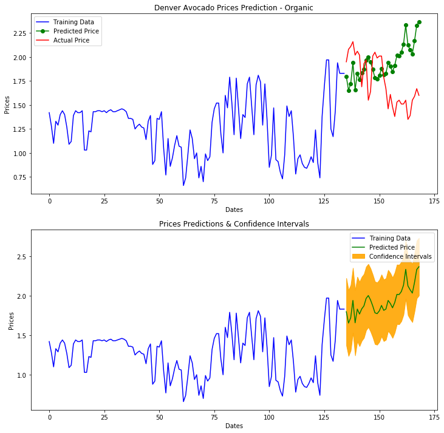

```python
fig, axes = plt.subplots(2, 1, figsize=(12, 12))
axes[0].plot(y_train, color='blue', label='Training Data')
axes[0].plot(test_data.index, forecasts, color='green', marker='o',label='Predicted Price')

axes[0].plot(test_data.index, y_test, color='red', label='Actual Price')
axes[0].set_title('Denver Avocado Prices Prediction - Organic')
axes[0].set_xlabel('Dates')
axes[0].set_ylabel('Prices')
axes[0].legend()


axes[1].plot(y_train, color='blue', label='Training Data')
axes[1].plot(test_data.index, forecasts, color='green',
             label='Predicted Price')

axes[1].set_title('Prices Predictions & Confidence Intervals')
axes[1].set_xlabel('Dates')
axes[1].set_ylabel('Prices')

conf_int = np.asarray(confidence_intervals)
axes[1].fill_between(test_data.index,
                     conf_int[:, 0], conf_int[:, 1],
                     alpha=0.9, color='orange',
                     label="Confidence Intervals")
axes[1].legend()
```